#### Dragos Ailoae

2022-04-07

# Binary Choice Models

## Predicted Probabilities and Estimated Effects

In [lab 8](https://www747.github.io/NYU1102/Lab8/Lab8.html) we modeled married women's labor participation decision using OLS, probit, and logistic regression.

```r
rm(list=ls())    # Removes all items in Environment!
#
# OPTIONS:
options(warn=-1) # Suppress warnings
options(repr.plot.width = 6, repr.plot.height = 6)
#
# LOAD PACKAGES:
packages <- c("foreign","tidyverse","modelsummary","mfx")
zzz <- lapply(packages, function(xxx) suppressMessages(require(xxx,
               character.only = TRUE, quietly=TRUE, warn.conflicts = FALSE)))
#
# Load Data
raw.data <- read.dta("http://fmwww.bc.edu/ec-p/data/wooldridge/mroz.dta")
my.df <- data.frame(raw.data)
#
# Evaluate 3 models
equation <- inlf ~ nwifeinc + educ + exper + expersq + age + kidslt6 + kidsge6
LPM <- lm(equation, data = my.df)
probit_glm <- glm(equation, data = my.df, family = binomial(link = "probit"))
logit_glm <- glm(equation, data = my.df, family = binomial(link = "logit"))
#
# Output table
models <- list(LPM = LPM, Probit = probit_glm, Logit = logit_glm)
modelsummary(models, title ="Labor force participation models",
             fmt = "%.3f",stars = TRUE,group = model ~ term,
             gof_omit = ".*") %>% as.character %>% IRdisplay::display_html()
```

Labor force participation models

|  | (Intercept) | nwifeinc | educ | exper | expersq | age | kidslt6 | kidsge6 |
| --- | --- | --- | --- | --- | --- | --- | --- | --- |
| LPM | 0.586*** | −0.003* | 0.038*** | 0.039*** | −0.001** | −0.016*** | −0.262*** | 0.013 |
|  | (0.154) | (0.001) | (0.007) | (0.006) | (0.000) | (0.002) | (0.034) | (0.013) |
| Probit | 0.270 | −0.012* | 0.131*** | 0.123*** | −0.002** | −0.053*** | −0.868*** | 0.036 |
|  | (0.508) | (0.005) | (0.025) | (0.019) | (0.001) | (0.008) | (0.118) | (0.044) |
| Logit | 0.425 | −0.021* | 0.221*** | 0.206*** | −0.003** | −0.088*** | −1.443*** | 0.060 |
|  | (0.860) | (0.008) | (0.043) | (0.032) | (0.001) | (0.015) | (0.204) | (0.075) |

+ p < 0.1, * p < 0.05, ** p < 0.01, *** p < 0.001

On first inspection, the three regressions seem to point to very different magnitudes of effects. While we intuitively understand the OLS coefficients, how should we interpret the Probit and Logit coefficients?

To understand this we'll need a bit of theory:

### LPM Problem

The linear probability model assumes the conditional probability function to be linear. This does not restrict $P\left(Y=1 \mid X_{1}, \ldots, X_{k}\right)$ to lie between 0 and 1.

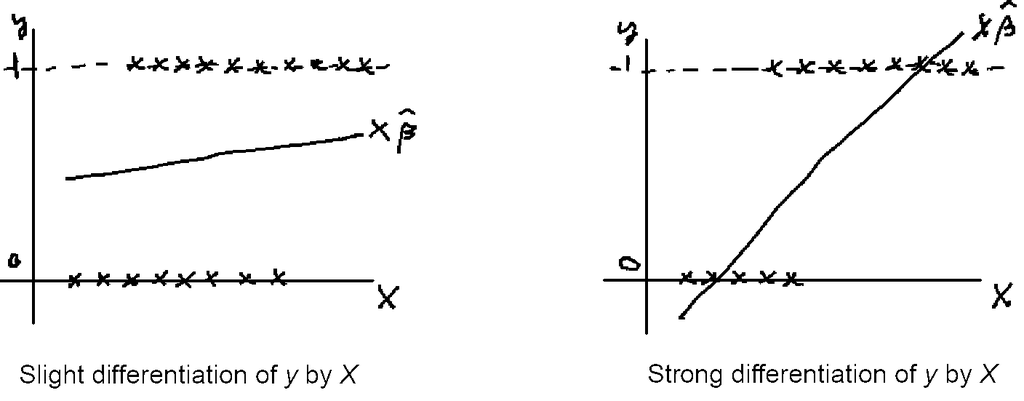

### Solution: Index (link) functions

Function that maps the linear relationship ranging from negative infinity to positive infinity to nonlinear probability ranging between 0 and 1.

### Probit

The link function used in probit regression is the standard normal distribution CDF.

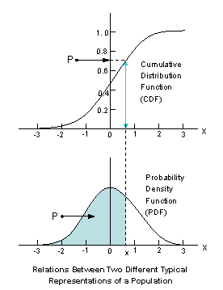

Probit regression coefficients therefore tell us the change in the outcome Z-score for a 1 unit change in X evaluated at the data sample means.

As a refresher let's look at the statistical table for the [standard normal](https://www747.github.io/NYU1102/Admin/StatsTables.pdf#page=2).

In R, we can compute the change in probabilities at the mean as follows (here for the kidslt6 coefficient):

```r
round(pnorm(.5 - 0.868) - pnorm(.5),2)
```

-0.34

The 'mfx' package in R allows us to compute marginal effects for nonlinear regressions:

```r
probitmfx(equation, atmean=TRUE, data=my.df)
```

```
Call:
probitmfx(formula = equation, data = my.df, atmean = TRUE)

Marginal Effects:
               dF/dx   Std. Err.       z     P>|z|
nwifeinc -0.00469619  0.00192965 -2.4337  0.014945 *
educ      0.05112843  0.00992310  5.1525 2.571e-07 ***
exper     0.04817690  0.00734505  6.5591 5.413e-11 ***
expersq  -0.00073705  0.00023464 -3.1412  0.001683 **
age      -0.02064309  0.00330485 -6.2463 4.203e-10 ***
kidslt6  -0.33914996  0.04634765 -7.3175 2.526e-13 ***
kidsge6   0.01406306  0.01719895  0.8177  0.413546
---
Signif. codes:  0 '***' 0.001 '**' 0.01 '*' 0.05 '.' 0.1 ' ' 1
```

These marginal effects are more in line with the OLS estimates.

### Logit

The link function used in logistic regression is based on the binomial distribution and is known as logit. To understand logit we need to first understand odds (odds ratios).

#### From probability to odds to log of odds

Everything starts with the concept of probability. Let’s say that the probability of success of some event is .8. Then the probability of failure is 1 – .8 = .2. The odds of success are defined as the ratio of the probability of success over the probability of failure. In our example, the odds of success are .8/.2 = 4. That is to say that the odds of success are 4 to 1. If the probability of success is .5, i.e., 50-50 percent chance, then the odds of success is 1 to 1.

For another example, consider dice: the probability of rolling a 3 is 1/6. But the odds of rolling a 3 is 1 to 5 or 1/5.

The table below shows the relationship between probability, odds and log of odds.

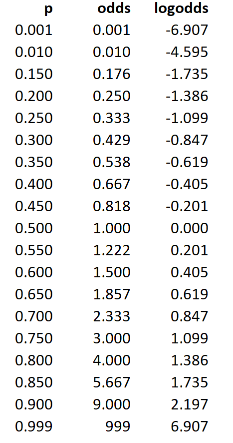

Note how we've achieved our goal of mapping probability, ranging between 0 and 1, to log-odds, ranging from negative infinity to infinity.

So, to convert the logit glm output to probability we need to:

1. Take glm output coefficient (logit)
2. Exponentiate (or "de-logarithimize")
3. Convert odds to probability using this formula prob = odds / (1 + odds)

The "modelsummary" package can report exponentiated logit coefficients (i.e. in odds terms rather than log-odds). Note however that it does not adjust standard errors so best to just report the t-values:

```r
modelsummary(logit_glm ,title ="Logit (LogOdds)", fmt = "%.3f",stars = FALSE,
             exponentiate = FALSE,group = model ~ term,
             gof_omit = ".*"
             ) %>% as.character %>% IRdisplay::display_html()

modelsummary(logit_glm ,title ="Exponentiated Logit (Odds)", fmt = "%.3f",stars = FALSE,
             exponentiate = TRUE,group = model ~ term,
             gof_omit = ".*",statistic = "t = {statistic}"
             ) %>% as.character %>% IRdisplay::display_html()
```

Logit (LogOdds)

|  | (Intercept) | nwifeinc | educ | exper | expersq | age | kidslt6 | kidsge6 |
| --- | --- | --- | --- | --- | --- | --- | --- | --- |
| Model 1 | 0.425 | −0.021 | 0.221 | 0.206 | −0.003 | −0.088 | −1.443 | 0.060 |
|  | (0.860) | (0.008) | (0.043) | (0.032) | (0.001) | (0.015) | (0.204) | (0.075) |

Exponentiated Logit (Odds)

|  | (Intercept) | nwifeinc | educ | exper | expersq | age | kidslt6 | kidsge6 |
| --- | --- | --- | --- | --- | --- | --- | --- | --- |
| Model 1 | 1.530 | 0.979 | 1.248 | 1.229 | 0.997 | 0.916 | 0.236 | 1.062 |
|  | t = 0.495 | t = −2.535 | t = 5.091 | t = 6.422 | t = −3.104 | t = −6.040 | t = −7.090 | t = 0.804 |

Looking at the *kidslt6* coefficient, this tells us that an increase of 1 in the independent variable is associated with odds changing by a factor of 0.236. If we evaluate at the mean, i.e. odds = 1 this means a change in probability of:

```r
round(0.236 / (1 + 0.236) - 1 / (1 + 1), 2)
```

-0.31

This value is more in line with the OLS estimated probability change of -0.26.

As with probit, the 'mfx' package allows us to compute marginal effects:

```r
logitmfx(equation, atmean=TRUE, data=my.df)
```

```
Call:
logitmfx(formula = equation, data = my.df, atmean = TRUE)

Marginal Effects:
               dF/dx   Std. Err.       z     P>|z|
nwifeinc -0.00519005  0.00204820 -2.5340  0.011278 *
educ      0.05377731  0.01056074  5.0922 3.539e-07 ***
exper     0.05005693  0.00782462  6.3974 1.581e-10 ***
expersq  -0.00076692  0.00024768 -3.0965  0.001959 **
age      -0.02140302  0.00353973 -6.0465 1.480e-09 ***
kidslt6  -0.35094982  0.04963897 -7.0700 1.549e-12 ***
kidsge6   0.01461621  0.01818832  0.8036  0.421625
---
Signif. codes:  0 '***' 0.001 '**' 0.01 '*' 0.05 '.' 0.1 ' ' 1
```

### Partial Effects at the Average (PEA) vs. Average Partial Effects (APE)

With nonlinear regression there is no single uniform effect but the effect changes with X. With binary response models partial effects are reported either "at the mean/average" (PEA) or averaged over the distribution (APE).

The MFX computes both by specifying *atmean* as either TRUE or FALSE. Note that these estimates can be quite different, especially with dummy variables. Greene goes into some detail on this topic with Example 17.3:

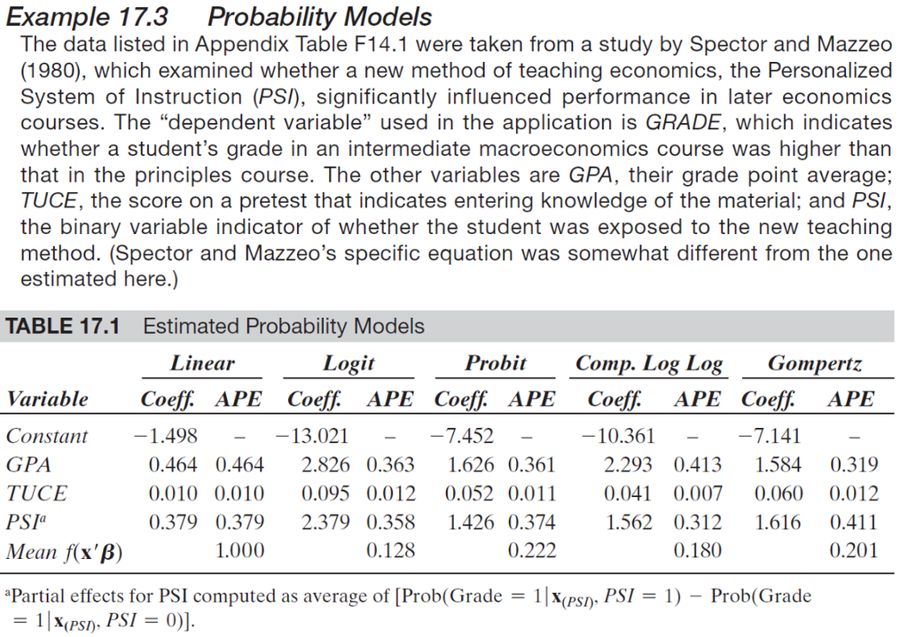

```r
mydata <- read.csv("spector.csv")
mydata$PSI <- factor(mydata$PSI)
equation <- GRADE ~ GPA + TUCE + PSI
LPM <- lm(equation, data=mydata)
logit_glm <- glm(equation, data=mydata,family=binomial(link=logit))
probit_glm <- glm(equation, data=mydata,family=binomial(link=probit))
models <- list(LPM = LPM, Logit = logit_glm,Probit = probit_glm)
modelsummary(models, fmt = "%.3f",stars = F,gof_omit = ".*"
             ) %>% as.character %>% IRdisplay::display_html()
```

|  | LPM | Logit | Probit |
| --- | --- | --- | --- |
| (Intercept) | −1.498 | −13.021 | −7.452 |
|  | (0.524) | (4.931) | (2.572) |
| GPA | 0.464 | 2.826 | 1.626 |
|  | (0.162) | (1.263) | (0.690) |
| TUCE | 0.010 | 0.095 | 0.052 |
|  | (0.019) | (0.142) | (0.081) |
| PSI1 | 0.379 | 2.379 | 1.426 |
|  | (0.139) | (1.065) | (0.587) |

Let's focus on the logit model. For the PSI variable, the PEAs are reported by mfx as:

```r
logitmfx(equation, atmean=TRUE, data=mydata)
```

```
Call:
logitmfx(formula = equation, data = mydata, atmean = TRUE)

Marginal Effects:
        dF/dx Std. Err.      z   P>|z|
GPA  0.533859  0.237037 2.2522 0.02431 *
TUCE 0.017975  0.026237 0.6851 0.49326
PSI1 0.456498  0.181053 2.5214 0.01169 *
---
Signif. codes:  0 '***' 0.001 '**' 0.01 '*' 0.05 '.' 0.1 ' ' 1

dF/dx is for discrete change for the following variables:

[1] "PSI1"
```

While the APEs:

```r
logitmfx(equation, atmean=FALSE, data=mydata)
```

```
Call:
logitmfx(formula = equation, data = mydata, atmean = FALSE)

Marginal Effects:
        dF/dx Std. Err.      z   P>|z|
GPA  0.362581  0.240049 1.5104 0.13093
TUCE 0.012208  0.019036 0.6413 0.52131
PSI1 0.357515  0.142003 2.5177 0.01181 *
---
Signif. codes:  0 '***' 0.001 '**' 0.01 '*' 0.05 '.' 0.1 ' ' 1

dF/dx is for discrete change for the following variables:

[1] "PSI1"
```

Note the big PEA-APE difference in the marginal effects for PSI and GPA. To understand why let's plot the response function (GRADE) as a function of PSI and GPA while keeping TUCE constant (at the mean):

```r
plot.data <- with(mydata, data.frame(GPA = rep(seq(from = 2, to = 4, length.out = 100),
    4), TUCE = mean(TUCE), PSI = factor(rep(0:1, each = 100))))

plot.data <- cbind(plot.data, predict(logit_glm, plot.data, type = "link", se = TRUE))

plot.data <- within(plot.data, {
    PredictedProb <- plogis(fit)
    LL <- plogis(fit - (1.96 * se.fit))
    UL <- plogis(fit + (1.96 * se.fit))
})

head(plot.data)
```

| GPA | TUCE | PSI | fit | se.fit | residual.scale | UL | LL | PredictedProb |
| --- | --- | --- | --- | --- | --- | --- | --- | --- |
| 2.000000 | 21.9375 | 0 | -5.281600 | 1.901440 | 1 | 0.1743972 | 0.0001223597 | 0.005058568 |
| 2.020202 | 21.9375 | 0 | -5.224507 | 1.878165 | 1 | 0.1760556 | 0.0001355938 | 0.005354190 |
| 2.040404 | 21.9375 | 0 | -5.167414 | 1.854950 | 1 | 0.1777432 | 0.0001502417 | 0.005666990 |
| 2.060606 | 21.9375 | 0 | -5.110321 | 1.831795 | 1 | 0.1794611 | 0.0001664517 | 0.005997954 |
| 2.080808 | 21.9375 | 0 | -5.053228 | 1.808704 | 1 | 0.1812104 | 0.0001843874 | 0.006348123 |
| 2.101010 | 21.9375 | 0 | -4.996135 | 1.785679 | 1 | 0.1829923 | 0.0002042290 | 0.006718598 |

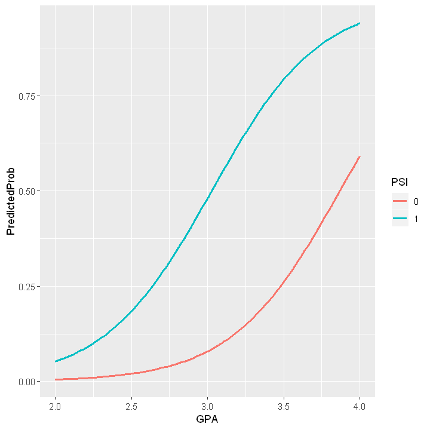

```r
ggplot(plot.data, aes(x = GPA, y = PredictedProb)) + geom_line(aes(colour = PSI), size = 1)
```

The simple estimate of the partial effect at the mean is 0.456. But of course, this calculation does not show the wide range of differences displayed visible in the plot above. The APE averages over the entire distribution, and equals 0.358. This latter figure is probably more representative of the desired effect.